# DATA 606 Chapter 4 Homework

Yohannes Deboch

March 2, 2019

4.4 Heights of adults. Researchers studying anthropometry collected body girth measurements and skeletal diameter measurements, as well as age, weight, height and gender, for 507 physically active individuals.

1. What is the point estimate for the average height of active individuals? What about the median? (See the next page for parts (b)-(e).)

Answer: The point estimate is mean 171.1cm. The median is 170.3cm.

2. What is the point estimate for the standard deviation of the heights of active individuals?

What about the IQR?

Answer: The point estimated for the standard deviation is 9.4cm. The IQR is 14cm

```r
# IQR = Q3 - Q1
177.8 - 163.8
```

```
## [1] 14
```

3. Is a person who is 1m 80cm (180 cm) tall considered unusually tall? And is a person who is 1m 55cm (155cm) considered unusually short? Explain your reasoning.

Answer: We first find Z value of 180cm and 155 cm.

```r
mean <- 171.1
sd <- 9.4
(180-mean)/sd
```

```
## [1] 0.9468085
```

```r
(155-mean)/sd
```

```
## [1] -1.712766
```

Z value of 180 is 0.9468085 and Z value of 155 is -1.712766.

180 cm is within 1 standard deviation of the mean which is not unusual.

4. The researchers take another random sample of physically active individuals. Would you expect the mean and the standard deviation of this new sample to be the ones given above? Explain your reasoning.

Answer: The new sample mean and standard deviation won’t be the ones given above. Because mean and standard deviation is point estimates for each sample drawn they’ll be different.

5. The sample means obtained are point estimates for the mean height of all active individuals, if the sample of individuals is equivalent to a simple random sample. What measure do we use to quantify the variability of such an estimate ? Compute this quantity using the data from the original sample under the condition that the data are a simple random sample

Answer: We use Standard Error to quantify the variability of such an estimate.

```r
9.4/sqrt(507)
```

```
## [1] 0.4174687
```

The standard error of the data is 0.4174687.

4.14 Thanksgiving spending, Part I. The 2009 holiday retail season, which kicked off on November 27, 2009 (the day after Thanksgiving), had been marked by somewhat lower self-reported consumer spending than was seen during the comparable period in 2008. To get an estimate of consumer spending, 436 randomly sampled American adults were surveyed. Daily consumer spending for the six-day period after Thanksgiving, spanning the Black Friday weekend and Cyber Monday, averaged $84.71. A 95% confidence interval based on this sample is ($80.31, $89.11).

Determine whether the following statements are true or false, and explain your reasoning.

1. We are 95% confident that the average spending of these 436 American adults is between $80.31 and $89.11.

Answer: FALSE.

We’re 95% confident that average spending of all americans on Black Friday we’ll be between $80.31 and $89.11.

2. This confidence interval is not valid since the distribution of spending in the sample is right skewed. Answer: FALSE. The confidence interval interval is valid since the Sample Size is large and for large sample the distribution is approximately normal using Central Limit Therom of Probability distributions.
3. 95% of random samples have a sample mean between $80.31 and $89.11. Answer: TRUE. The confidence interval of the sample tells that 95% of random samples have a sample mean between $80.31 and $89.11 which is based on sample distribution.
4. We are 95% confident that the average spending of all American adults is between $80.31 and $89.11. Answer: True. We’er 95% confident that the population average spending lies between $80.31 and $89.11.
5. A 90% confidence interval would be narrower than the 95% confidence interval since we don’t need to be as sure about our estimate. Answer: True. Since we’ll be less sure about the average wpi;d fall insdie 90% confidence interval.
6. In order to decrease the margin of error of a 95% confidence interval to a third of what it is now, we would need to use a sample 3 times larger. Answer: False. ME = z*SE and SE = sd/sqrt(n). For decreasing margin of error by 1/3 we need to increase the sample size 9 times of n.
7. The margin of error is 4.4 Answer: True, Margin of error is half of the confidence interval.

```r
(89.11 - 80.31) / 2
```

```
## [1] 4.4
```

1. Are conditions for inference satisfied? Answer: The condition of large sample is satisfied, the independence of the samples drawn are satisfied since the childrens are drawn at random and the assmuption of normality is satisfied since the childrens age are approximately normally distributed.
2. Suppose you read online that children first count to 10 successfully when they are 32 months old, on average. Perform a hypothesis test to evaluate if these data provide convincing evidence that the average age at which gifted children first count to 10 successfully is less than the general average of 32 months. Use a significance level of 0.10. Answer: $Null Hypothesis:\mu_{gifted} = 32$

$Alternative Hypothesis:\mu_{gifted} < 32$

```r
se <- 4.31/sqrt(36)
z <- (30.69-32)/se
z
```

```
## [1] -1.823666
```

```r
pnorm(z)
```

```
## [1] 0.0341013
```

```r
30.69 + qnorm(0.95)*se
```

```
## [1] 31.87155
```

```r
30.69 - qnorm(0.95)*se
```

```
## [1] 29.50845
```

90% confidence interval for the average age at which gifted children first count to 10 successfully is (29.50845,31.87155 ) (e) Do your results from the hypothesis test and the confidence interval agree? Explain. Answer: Yes. The result of the hypothesis test and the confidence interval agree. Since the sample mean lies within the confidence interval.

$Alternative Hypothesis:\mu_{gifted} ≠ 100$

```r
se <- 6.5/sqrt(36)
z <- (118.2-100)/se
z
```

```
## [1] 16.8
```

```r
pnorm(-z)*2
```

```
## [1] 2.44044e-63
```

```r
118.2 + qnorm(0.95)*se
```

```
## [1] 119.9819
```

```r
118.2 - qnorm(0.95)*se
```

```
## [1] 116.4181
```

90% confidence interval for the average IQ of mothers of gifted children is (116.4181, 119.9819)

3. Do your results from the hypothesis test and the confidence interval agree? Explain

Answer: Yes. The result of the hypothesis test and the confidence interval agree. Since the sample mean IQ of mothers lies within the confidence interval.

4.34 CLT. Define the term “sampling distribution” of the mean, and describe how the shape, center, and spread of the sampling distribution of the mean change as sample size increases. Answer: “sampling distribution” of the mean is the distribution of randomly drawn independent sample means from a population. By CLT the as sample size increases the shape, center and spread of the sampling distributions approximates to the shape, center and spread of a normal distribution.

4.40 CFLBs. A manufacturer of compact fluorescent light bulbs advertises that the distribution of the lifespans of these light bulbs is nearly normal with a mean of 9,000 hours and a standard deviation of 1,000 hours.

1. What is the probability that a randomly chosen light bulb lasts more than 10,500 hours? Answer:

```r
pnorm(10500,9000,1000, lower.tail = FALSE)
```

```
## [1] 0.0668072
```

The probability is 0.0668072.

2. Describe the distribution of the mean lifespan of 15 light bulbs. Answer:

```r
1000/sqrt(15)
```

```
## [1] 258.1989
```

The sampling distribution of 15 light bulb is approximately normally distributed with mean 9000 and standerd deviation 258.1989. (c) What is the probability that the mean lifespan of 15 randomly chosen light bulbs is more than 10,500 hours? Answer:

```r
pnorm(10500,9000,258.1989, lower.tail = FALSE)
```

```
## [1] 3.133457e-09
```

The probability that the mean lifespan of 15 randomly chosen light bulbs is more than 10,500 hours is almost 0. (d) Sketch the two distributions (population and sampling) on the same scale. Answser:

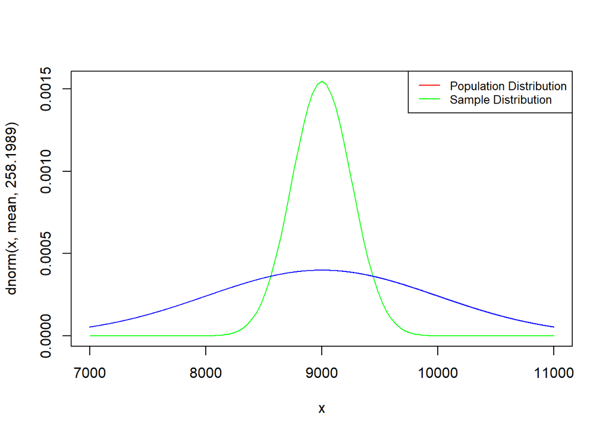

```r
colors <- c("red", "green")
mean <- 9000
x <- seq(7000, 11000, 1)
y <- dnorm(x,mean, 1000)
curve(dnorm(x, mean, 258.1989), 7000, 11000, col="green")
lines(x = x, y = y, col = "blue")
legend("topright", legend=c("Population Distribution", "Sample Distribution"),
       col=c("red", "green"), lty=1, cex=0.8)
```

5. Could you estimate the probabilities from parts (a) and (c) if the lifespans of light bulbs had a skewed distribution?

Answer: I couldn’t estimated the probabilities from parts (a) and (c) if the lifespans of light bulbs had a skewed distribution.

4.48 Same observation, different sample size. Suppose you conduct a hypothesis test based on a sample where the sample size is n = 50, and arrive at a p-value of 0.08. You then refer back to your notes and discover that you made a careless mistake, the sample size should have been n = 500. Will your p-value increase, decrease, or stay the same? Explain. Answer: P value will decrease since larger sample size will give smaller standard error. Since n is the denominator of SE, which is used to calculate Z score for the calculation of p value.